# INFORME EDA (Exploratory Data Analysis) Y FASE ANALÍTICA 1

Este estudio exhaustivo aborda el dataset de OWID desde 0, ignorando preconcepciones para encontrar el peso real de cada métrica.

```python
import pandas as pd
import numpy as np
import matplotlib.pyplot as plt
import seaborn as sns
from IPython.display import display
warnings = __import__('warnings')
warnings.filterwarnings('ignore')
sns.set_theme(style='whitegrid')
```

## PARTE I: Ingesta y Diagnóstico Exploratorio Básico

Inspeccionamos peso, tipos de datos y matriz de nulos (Missingness).

```python
url = 'https://raw.githubusercontent.com/owid/co2-data/master/owid-co2-data.csv'
raw_df = pd.read_csv(url)
print(f'Dimensiones Iniciales: {raw_df.shape}')
display(raw_df.info())
```

```
Dimensiones Iniciales: (50411, 79)
<class 'pandas.core.frame.DataFrame'>
RangeIndex: 50411 entries, 0 to 50410
Data columns (total 79 columns):
 #   Column                                     Non-Null Count  Dtype
---  ------                                     --------------  -----
 0   country                                    50411 non-null  object
 1   year                                       50411 non-null  int64
 2   iso_code                                   42480 non-null  object
 3   population                                 41167 non-null  float64
 4   gdp                                        15251 non-null  float64
 5   cement_co2                                 29173 non-null  float64
 6   cement_co2_per_capita                      25648 non-null  float64
 7   co2                                        29384 non-null  float64
 8   co2_growth_abs                             27216 non-null  float64
```

[output cut: 72 more lines]

```
None
```

### Variables Financieras y Demográficas Disponibles

Aislamos columnas clave para ver qué podemos correlacionar (gdp, population, primary_energy_consumption, y todos los gases: co2, methane, nitrous_oxide).

```python
cols = ['country', 'year', 'iso_code', 'population', 'gdp', 'co2', 'methane', 'nitrous_oxide', 'primary_energy_consumption', 'co2_per_capita']
df_core = raw_df[cols].copy()
display(df_core.head())
```

|  | country | year | iso_code | population | gdp | co2 | methane | nitrous_oxide | primary_energy_consumption | co2_per_capita |
| --- | --- | --- | --- | --- | --- | --- | --- | --- | --- | --- |
| 0 | Afghanistan | 1750 | AFG | 2802560.0 | NaN | NaN | NaN | NaN | NaN | NaN |
| 1 | Afghanistan | 1751 | AFG | NaN | NaN | NaN | NaN | NaN | NaN | NaN |
| 2 | Afghanistan | 1752 | AFG | NaN | NaN | NaN | NaN | NaN | NaN | NaN |
| 3 | Afghanistan | 1753 | AFG | NaN | NaN | NaN | NaN | NaN | NaN | NaN |
| 4 | Afghanistan | 1754 | AFG | NaN | NaN | NaN | NaN | NaN | NaN | NaN |

### Matriz de Valores Faltantes por Década

Identificamos a partir de qué era moderna tenemos datos útiles y robustos.

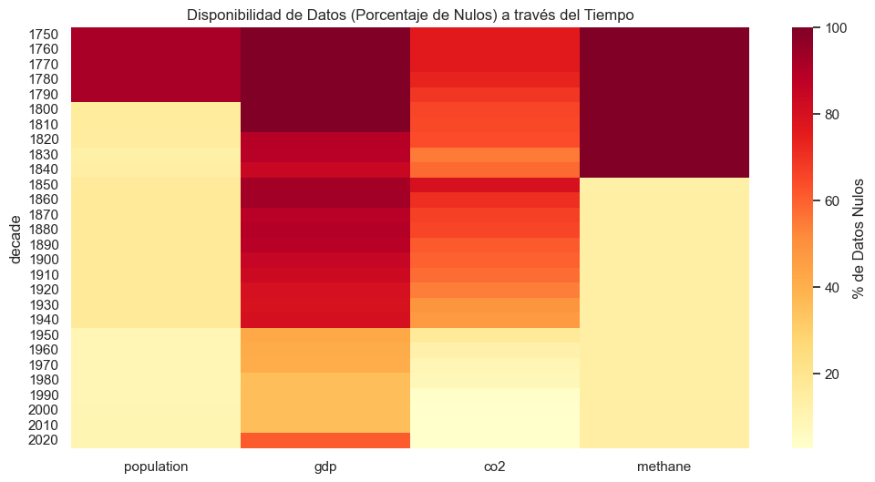

```python
df_core['decade'] = (df_core['year'] // 10) * 10
missing_by_decade = df_core.groupby('decade').apply(lambda x: x.isnull().mean() * 100)
plt.figure(figsize=(12, 6))
sns.heatmap(missing_by_decade[['population', 'gdp', 'co2', 'methane']], cmap='YlOrRd', cbar_kws={'label': '% de Datos Nulos'})
plt.title('Disponibilidad de Datos (Porcentaje de Nulos) a través del Tiempo')
plt.show()
```

## PARTE II: Purgado de Datos (ISO Standard)

Retiramos los continentes y bloques globales para aislar naciones viables.

```python
df_countries = df_core[df_core['iso_code'].notna() & ~df_core['iso_code'].str.startswith('OWID', na=False)].copy()
print(f'Naciones Soberanas Viables aisladas: {df_countries.country.nunique()} países.')
display(df_countries['country'].sample(10).values)
```

```
Naciones Soberanas Viables aisladas: 218 países.
```

```
array(['Christmas Island', 'Bermuda', 'France', 'Aruba', 'Vietnam',
       'Aruba', 'Central African Republic', 'Bolivia', 'Malta',
       'San Marino'], dtype=object)
```

### Distribución de Emisiones CO2 a Nivel Global (Sin Nulos Temporales)

Buscamos Outliers. ¿Qué tipo de distribución estadística sigue el carbono?

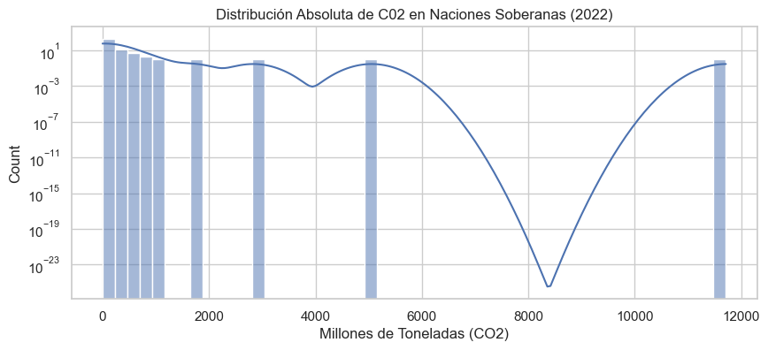

```
Observación: Distribución fuertemente asimétrica a la derecha. Pocos países emiten casi todo el carbono.
```

```python
modern_df = df_countries[df_countries['year'] == 2022] # Usamos un año muy reciente y completo
plt.figure(figsize=(10, 4))
sns.histplot(modern_df['co2'].dropna(), bins=50, kde=True)
plt.title('Distribución Absoluta de C02 en Naciones Soberanas (2022)')
plt.xlabel('Millones de Toneladas (CO2)')
plt.yscale('log')
plt.show()
print("Observación: Distribución fuertemente asimétrica a la derecha. Pocos países emiten casi todo el carbono.")
```

## PARTE III: Matriz de Correlaciones Univariables

¿Es la población o el PIB el principal detonante del CO2? Usamos correlación de Spearman para eludir Outliers.

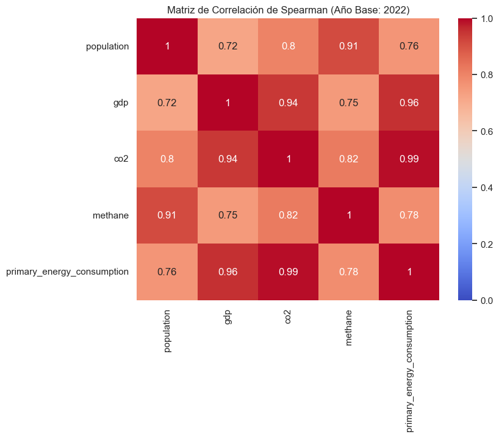

|  | population | gdp | co2 | methane | primary_energy_consumption |
| --- | --- | --- | --- | --- | --- |
| population | 1.000000 | 0.719685 | 0.801446 | 0.912291 | 0.757999 |
| gdp | 0.719685 | 1.000000 | 0.941978 | 0.746529 | 0.955314 |
| co2 | 0.801446 | 0.941978 | 1.000000 | 0.817446 | 0.988336 |
| methane | 0.912291 | 0.746529 | 0.817446 | 1.000000 | 0.779893 |
| primary_energy_consumption | 0.757999 | 0.955314 | 0.988336 | 0.779893 | 1.000000 |

```python
corrmat = modern_df[['population', 'gdp', 'co2', 'methane', 'primary_energy_consumption']].corr(method='spearman')
plt.figure(figsize=(8, 6))
sns.heatmap(corrmat, annot=True, cmap='coolwarm', vmin=0, vmax=1)
plt.title('Matriz de Correlación de Spearman (Año Base: 2022)')
plt.show()
display(corrmat)
```

### El Factor 'Methane' y otros GEI olvidados

Verificamos la proporción de emisión de metano frente a CO2 puro.

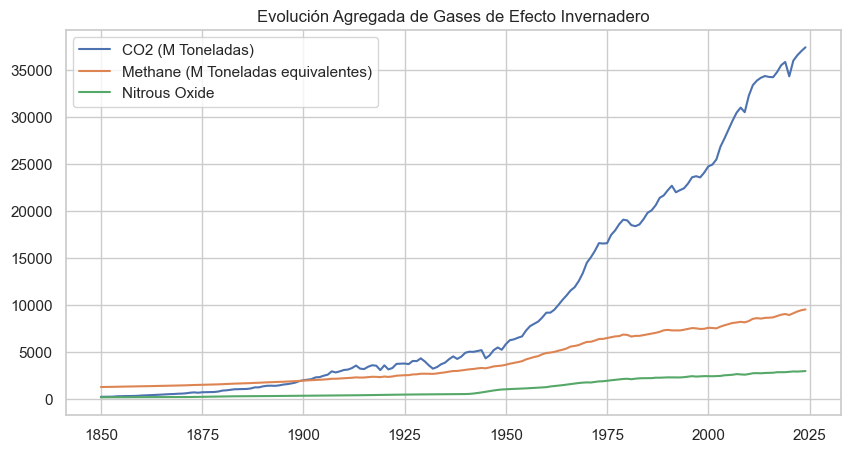

```python
df_gei = df_countries.groupby('year')[['co2', 'methane', 'nitrous_oxide']].sum().replace(0, np.nan).dropna()
plt.figure(figsize=(10, 5))
plt.plot(df_gei.index, df_gei['co2'], label='CO2 (M Toneladas)')
plt.plot(df_gei.index, df_gei['methane'], label='Methane (M Toneladas equivalentes)')
plt.plot(df_gei.index, df_gei['nitrous_oxide'], label='Nitrous Oxide')
plt.title('Evolución Agregada de Gases de Efecto Invernadero')
plt.legend()
plt.show()
```

## PARTE IV: Diagnóstico Analítico y Desigualdad

Si la riqueza es la que quema carbono: dividimos el mundo en Cuartiles de Riqueza (PIB Per Cápita).

```python
modern_df['gdp_pc'] = modern_df['gdp'] / modern_df['population']
quartiles = pd.qcut(modern_df['gdp_pc'].dropna(), q=4, labels=['Bajo (Q1)', 'Medio-Bajo (Q2)', 'Medio-Alto (Q3)', 'Alto (Q4)'])
modern_df['Riqueza'] = quartiles

riqueza_stats = modern_df.groupby('Riqueza')[['co2', 'population']].sum()
riqueza_stats['CO2_share_%'] = (riqueza_stats['co2'] / riqueza_stats['co2'].sum()) * 100
riqueza_stats['Pop_share_%'] = (riqueza_stats['population'] / riqueza_stats['population'].sum()) * 100
display(riqueza_stats)
```

| Riqueza | co2 | population | CO2_share_% | Pop_share_% |
| --- | --- | --- | --- | --- |
| Bajo (Q1) | 373.390 | 1.000894e+09 | 1.023611 | 12.652625 |
| Medio-Bajo (Q2) | 6016.511 | 3.108822e+09 | 16.493664 | 39.299616 |
| Medio-Alto (Q3) | 17884.414 | 2.622181e+09 | 49.028335 | 33.147840 |
| Alto (Q4) | 12203.395 | 1.178668e+09 | 33.454389 | 14.899919 |

### Visualizando la Injusticia Gini del CO2

¿El 25% más rico emite cuánto del total?

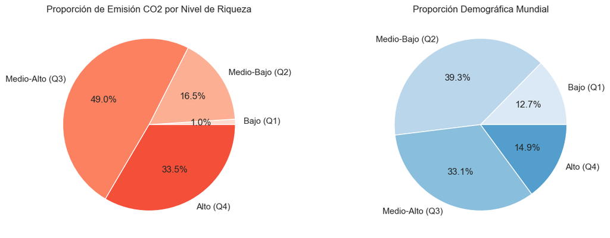

```python
fig, axes = plt.subplots(1, 2, figsize=(14, 5))
axes[0].pie(riqueza_stats['CO2_share_%'], labels=riqueza_stats.index, autopct='%1.1f%%', colors=sns.color_palette('Reds'))
axes[0].set_title('Proporción de Emisión CO2 por Nivel de Riqueza')
axes[1].pie(riqueza_stats['Pop_share_%'], labels=riqueza_stats.index, autopct='%1.1f%%', colors=sns.color_palette('Blues'))
axes[1].set_title('Proporción Demográfica Mundial')
plt.show()
```

Identificamos las matrices líderes de emisión en cortes de 50 años (1920, 1970, 2022).

```python
years = [1920, 1970, 2022]
for y in years:
    top = df_countries[df_countries['year'] == y].nlargest(5, 'co2')[['country', 'co2']]
    print(f'\n--- TOP 5 EN EL AÑO {y} ---')
    display(top)
```

```
--- TOP 5 EN EL AÑO 1920 ---
```

|  | country | co2 |
| --- | --- | --- |
| 47903 | United States | 1747.167 |
| 47678 | United Kingdom | 480.472 |
| 18215 | Germany | 429.208 |
| 17279 | France | 151.778 |
| 8773 | Canada | 84.378 |

```
--- TOP 5 EN EL AÑO 1970 ---
```

|  | country | co2 |
| --- | --- | --- |
| 47953 | United States | 4339.704 |
| 38260 | Russia | 1441.379 |
| 18265 | Germany | 1025.802 |
| 9879 | China | 807.964 |
| 23758 | Japan | 769.748 |

```
--- TOP 5 EN EL AÑO 2022 ---
```

|  | country | co2 |
| --- | --- | --- |
| 9931 | China | 11711.808 |
| 48005 | United States | 5055.403 |
| 21760 | India | 2831.132 |
| 38312 | Russia | 1675.461 |
| 23810 | Japan | 1029.645 |